# Project Proposal

Mark Gallo

# **Final Project Proposal**

#### **Title:** “A Collection of The Necessary Data to Compare Concert Ticket Prices Across Online Sellers”

#### **Type of Project:** Data (A1)

#### **Links to Data Sources:**

##### Spotify: https://api.spotify.com/v1/playlists

##### Seat Geek: https://api.seatgeek.com/2/events?

##### Ticket Master: https://app.ticketmaster.com/discovery/v2/events.json?

##### Last.FM: http://ws.audioscrobbler.com/2.0/

### 1. Significant Hurdles:

> > I wish to leverage the Stubhub and Apple Music APIs as well. However to obtain access to Stubhub data requires a user name and password input before being provided access to the data. There are a number of explinations of how to accomplish this using python, but I am having trouble doing this successfully in R. Any insight would be greatly appreciated. In the case of Apple Music, there is a $100 cost associated with getting access to the data. I am working on getting the data for free, as I am friends with an IOS developer. I must make it clear that if the data cannot be aquired for free than Apple Music’s API will not be leveraged for this project, as the cost would be too burdensome.

# **A Collection of The Necessary Data to Compare Concert Ticket Prices Across Online Sellers**

### 2. Overview

> > The intent of conducting this data collection is to make it simpler for users to compare ticket prices for upcomming concerts. Functions have been made that allow for a user to search for performers outside of the examples seen in the data set provided below. The intent is to assure that the data collection is done as to inform the user.

### 3. Data & Methodology

**Artist:** The Name of the artist of interest

**Next Show: City:** The City that the performer will be performing in next

**State:** US State show will be in

**Data & Time:** Date and Time of performers next show

**Seat Geek Avg Price:** Seat Geek avg price for next show

**2020 Ticket Master Forcast:** Expected average price for performer’s 2020 shows

**Genre Tags:** Music Genre & various tags

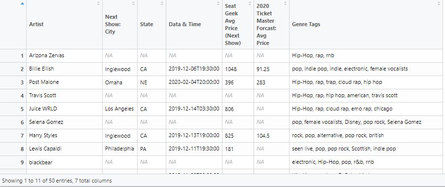

Data Example - All Data Seen Above Has Been Extracted From The APIs Listed in ‘Links to Data Sources’